# Tarea 8: redes

### Visualización

Empieza haciendo una gráfica simple:

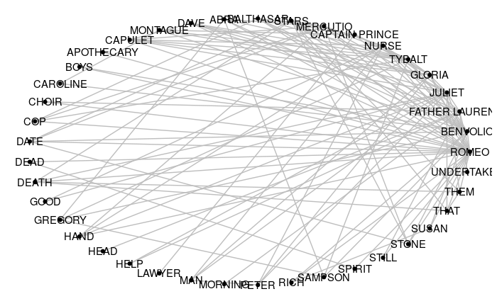

```r
ggraph(red_rj, layout = "circle") +
    geom_edge_link(colour = "gray") +
    geom_node_point() +
    geom_node_text(aes(label = label))
```

Ahora incluye tamaño y color en tu gráfica para los nodos. Puedes usar una medida de centralidad:

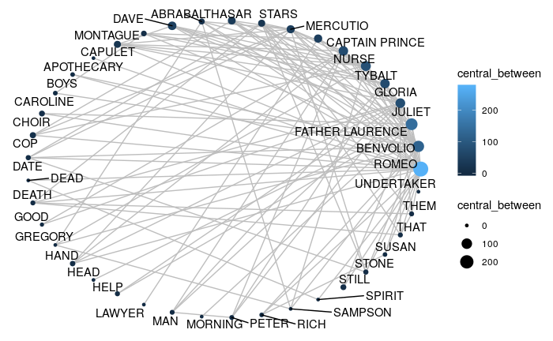

```r
ggraph(red_rj, layout = "circle") +
    geom_edge_link(colour = "gray") +
    geom_node_point(aes(size = central_between, colour = central_between)) +
    geom_node_text(aes(label = label), repel = TRUE)
```

Escoge un layout basado en fuerzas (puedes experimentar con *stress*, *fr*, *graphopt*, *gem*:

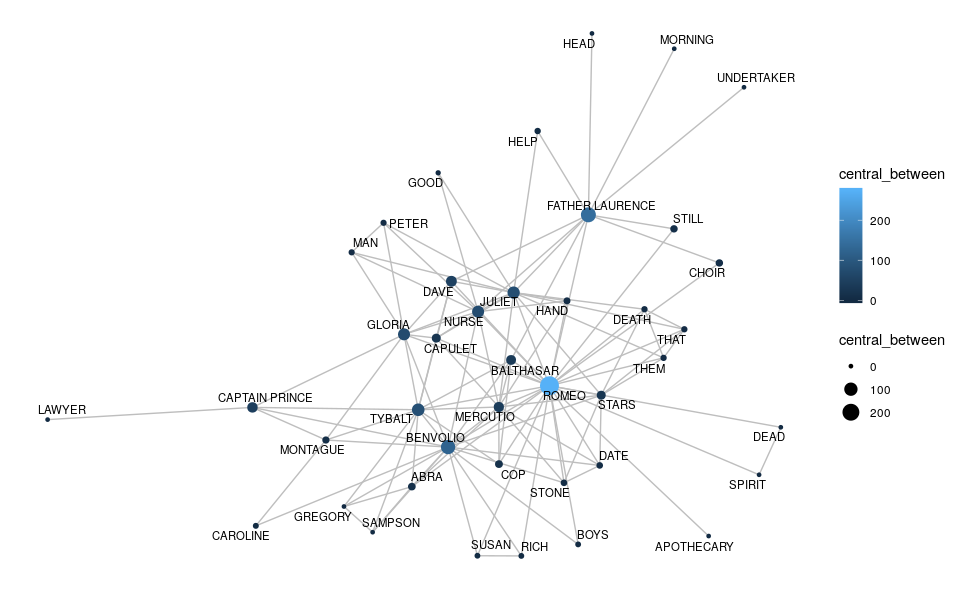

```r
ggraph(red_rj, layout = "fr") +
    geom_edge_link(colour = "gray") +
    geom_node_point(aes(size = central_between, colour = central_between)) +
    geom_node_text(aes(label = label), size = 3, repel = TRUE)
```

Agrega ancho de las aristas dependiendo del peso:

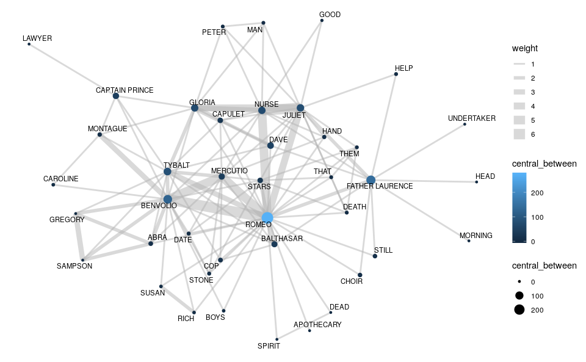

```r
ggraph(red_rj, layout = "stress") +
    geom_edge_link(aes(edge_width = weight), alpha = 0.5, colour = "gray70") +
    geom_node_point(aes(size = central_between, colour = central_between)) +
    geom_node_text(aes(label = label), size = 3, repel = TRUE)
```

Podemos usar el logaritmo de las medidas de centralidad para apreciar mejor variación:

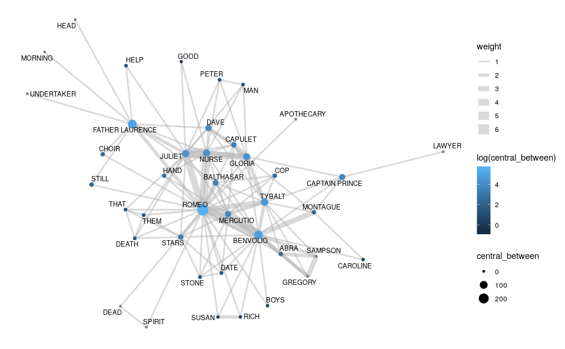

```r
set.seed(8823)
ggraph(red_rj, layout = "fr") +
    geom_edge_link(aes(edge_width = weight), alpha = 0.5, colour = "gray70") +
    geom_node_point(aes(size = central_between, colour = log(central_between))) +
    geom_node_text(aes(label = label), size = 3, repel = TRUE)
```

**Pregunta 4**. ¿qué algoritmos de layout funcioron mejor para tu gráfica? ¿Por qué?

**Pregunta 5**: en tu gráfica, ¿puedes explicar por qué algunos nodos son relativamente más importantes en una medida centralidad que en la otra?

**Pregunta 6** ¿Pudiste aprender algo de la estructura de la película examinando estas representaciones?